# Image processing with OpenCV

For tutorial week 6, our discussion and code samples will cover the following topics:

- Image smoothing and sharpening (Convolution in image processing)
- Image histograms
- Thresholding / Image binarization
- Morphological transformation
- Brief intro on several color spaces
- Examples of color based segmentation to detect object

```python
import sys
# Python 3.7 is required
assert sys.version_info >= (3,7)

import cv2 as cv
import numpy as np
import matplotlib.pyplot as plt

# Make sure that optimization is enabled
if not cv.useOptimized():
    cv.setUseOptimized(True)

cv.useOptimized()
```

```
True
```

## Introduction of convolution kernels in image processing

In image processing, a convolution kernel is a 2D matrix that is used to filter images. A convolution kernel is typically a square matrix, $M \times N$, where both *M* and *N* are odd integers.  
$ \begin {bmatrix} 1 & 1 & 1 \\ 1 & 1 & 1 \\ 1 & 1 & 1 \\ \end {bmatrix}$  
A $ 3 \times 3 $ 2D convolution kernel.

Such kernel can be used to perform mathematical operations on each pixel of an image to achieve a desired effect (like blurring or sharpening an image). But why would you want to blur an image? Here are 2 reasons:

- Because it reduces noise in an image.
- To remove a distinct background.

The value of individual elements in a kernel dictate the nature of filtering. For example, by changing the value of the kernel elements, you can also achieve sharpening effect.

## Smoothing images

### 2D convolution (Image Filtering)

As in one-dimensional signals, images also can be filtered with various low-pass filters (LPF), high-pass filters (HPF) and etc. LPF helps in removing noise, blurring images, etc. HPF filters help in finding edges in images.

OpenCV provides a function `cv.filter2D()` to convolve a kernel with an image.

```
cv.filter2D(src, ddepth, kernel, ...)
```

1. The first argument, src is source image.
2. ddepth indicates the depth of the resulting image. We will normally set it as -1 so that the final image will have the same depth as the source image, src.
3. kernel is the convolution matrix

### Example of identity kernel

```python
img = cv.imread('butterfly.jfif')
# define identity kernel
kernel = np.zeros((3, 3), dtype = np.uint8)
kernel[1, 1] = 1

identity = cv.filter2D(img, -1, kernel)

cv.imshow('original', img)
cv.imshow('Identity', identity)

cv.waitKey(0)
cv.destroyAllWindows()
```

[figure not shown]

```python
img = cv.imread('C:/Users/User/image processing/images/opencv_logo.png')
img = cv.cvtColor(img, cv.COLOR_BGR2RGB)    # because we are displaying using matplotlib module

kernel = np.ones((5,5), np.float32)/25
dst = cv.filter2D(img, -1, kernel)   # ddepth = -1 means that the processed image will have the same depth as the sources

plt.subplot(121), plt.imshow(img), plt.title('Original')
plt.xticks([]), plt.yticks([])
plt.subplot(122), plt.imshow(dst), plt.title('Averaging')
plt.xticks([]), plt.yticks([])
plt.show()
```

### Image Blurring (Image Smoothing)

Image blurring is achieved by convolving the image with a low-pass filter kernel. It is useful for removing nois, yet it also removes high frequency content (e.g. noise, edges) from the image. So edges are blurred a little bit in this operation (there are also blurring techniques which don't blur the edges). OpenCV provides four main types of blurring techniques.

1. Averaging. This is done by the function `cv.blur()` or `cv.boxFilter()`. We will use `cv.blur()` in the following example.

   ```
   cv.blur(src, ksize)
   ```

2. The first argument is the source image.
3. The second argument is the blurring kernel size. ($width, height$)

[figure not shown]

```python
blur = cv.blur(img, (5,5))

plt.subplot(121), plt.imshow(img), plt.title('Original')
plt.xticks([]), plt.yticks([])
plt.subplot(122), plt.imshow(blur), plt.title('Blurred')
plt.xticks([]), plt.yticks([])
plt.show()
```

1. Gaussian Blurring. This is done by `cv.GaussianBlur()`. We should specify the width and height of the kernel which should be positive and odd. We should also specify the standard deviation in the X and Y directions, sigmaX and sigmaY respectively. Better at preserving edges, but slower compared to its average counterparts

   ```
   cv.GaussianBlur(src, ksize, sigmaX, sigmaY, ...)
   ```

- First argument, src is the source image.
- ksize is the Gaussian kernel size ($width, height$)
- sigmaX is the Gaussian kernel standard deviation in X direction.
- sigmaY is the Gaussian kernel standard deviation in Y direction.
1. Median Blurring. This is done by `cv.medianBlur()`. Best in removing salt and pepper noise.
2. Bilateral filtering. This is done by `cv.bilateralFilter()`. It is highly effective in noise removal while keeping edges sharp. But the operation is slower compared to other filters.
   - Bilateral filtering takes a Gaussian filter in space, but one more Gaussian filter which is a function of pixel difference. The Gaussian function of space makes sure that only nearby pixels are considered for blurring, while Gaussian function of intensity difference ensures that only those pixels with similar intensities are considered for blurring.

## Exercise

- Apply different image smoothing techniques (e.g. average filter, Gaussian kernel and median filter) on 'noise_lena.jpg' and display the resulting images after the convolution. Comment on the outcomes and deduce the type of noise present on the image.

## Image sharpening by convolution kernel

```python
kernel = np.array([[0, -1, 0],
                  [-1, 5, -1],
                  [0, -1, 0]])

img = cv.imread('butterfly.jfif')
sharp_img = cv.filter2D(img, -1, kernel)

cv.imshow('original', img)
cv.imshow('sharpening', sharp_img)

cv.waitKey(0)
cv.destroyAllWindows()
```

## Activity

- Apply average kernel with increasing size on an image. What can you infer from the output images.
- Apply custom sharpening kernel of aperture size 3 and 5 as shown below on 'native-bee.png':  
  $ 3 \times 3 kernel:$  
  $ \begin{bmatrix} 0 & -1 & 0 \\ -1 & 5 & -1 \\ 0 & -1 & 0\\ \end{bmatrix}$  
  $ 5 \times 5 kernel:$  
  $ \begin{bmatrix} -1 & -1 & -1 & -1 & -1 \\ -1 & -1 & -1 & -1 & -1 \\ -1 & -1 & 25 & -1 & -1 \\ -1 & -1 & -1 & -1 & -1 \\ -1 & -1 & -1 & -1 & -1 \\ \end{bmatrix}$  
  What can you infer from the outputs?

## Histogram

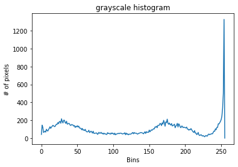

```python
img = cv.imread('butterfly.jfif')
img_gray = cv.cvtColor(img, cv.COLOR_BGR2GRAY)

hist = cv.calcHist([img_gray], [0], None, [256], [0, 255])

plt.figure()
plt.title('grayscale histogram')
plt.xlabel('Bins')
plt.ylabel('# of pixels')
plt.plot(hist)
plt.show()
```

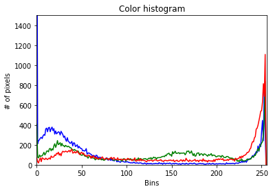

```python
# Color histogram
channels = cv.split(img)
colors = 'b', 'g', 'r'

plt.figure()
plt.title('Color histogram')
plt.xlabel('Bins')
plt.ylabel('# of pixels')

for (channel, color) in zip(channels, colors):
    hist = cv.calcHist([channel], [0], None, [256], [0, 255])
    plt.plot(hist, color = color)
    plt.xlim([0, 256])
    plt.ylim([0, 1500])

plt.show()
```

## Thresholding

What is thresholding? When the thresholding rule is applied to every pixel in the image, and the threshold value is fixed, the operation is called global.

The simplest form of global thresholding is called **binary thresholding**.

### Binary Thresholding

For every pixel, the same threshold value is applied. If the pixel value is smaller than the threshold, it is set to zero, otherwise it is set to a maximum value. The first argument is the source image, which should be a **grayscale** image. The second argument is the threshold value used to classify the pixel values. The third argument is the maximum value which is assigned to pixel values exceeding the threshold.

The method returns 2 outputs. The first is the threshold that was used and the second input is the thresholded image.

There are five different threshold types available in OpenCV.

## Simple thresholding

For every pixel, the same threshold is applied. If the pixel is smaller than the threshold, it is set to zero, otherwise it is set to the maximum.

```python
img = np.fromfunction(lambda i, j:j, (50, 256), dtype = 'uint8')

modes = (cv.THRESH_BINARY,
        cv.THRESH_BINARY_INV,
        cv.THRESH_TRUNC,
        cv.THRESH_TOZERO,
        cv.THRESH_TOZERO_INV)

def trackbar(x):
    ret, img1 = cv.threshold(img, x, 255, cv.THRESH_BINARY)
    ret, img2 = cv.threshold(img, x, 255, cv.THRESH_BINARY_INV)
    ret, img3 = cv.threshold(img, x, 255, cv.THRESH_TRUNC)
    ret, img4 = cv.threshold(img, x, 255, cv.THRESH_TOZERO)
    ret, img5 = cv.threshold(img, x, 255, cv.THRESH_TOZERO_INV)

    cv.imshow('window', np.vstack([img1, img2, img3, img4, img5]))

# cv.imshow('window', img)
trackbar(100)
cv.createTrackbar('threshold', 'window', 100, 255, trackbar)

cv.waitKey(0)
cv.destroyAllWindows()
```

### Adaptive thresholding

In the previous section, we used one global value as a threshold. But this might not be good in all cases, e.g. if an image has different lighting conditions in different areas. In that case, adaptive thresholding can help. Here the algorithm determines the threshold for a pixel based on a small region around it. So we get different thresholds for different regions of the same image which gives better results for images with varying illumination.

The `cv.adaptiveThreshold` function takes 3 input parameters:

- *adaptiveMethod* decides how the threshold value is calculated:
  - `cv.ADAPTIVE_THRESH_MEAN_C`: threshold value is mean of its neighborhood area minus C.
  - `cv.ADAPTIVE_THRESH_GAUSSIAN_C`: threshold value is gaussian-weighted sum of the neighborhood values minus C.
- *blockSize* determines the size of the neighborhood area
- *C* is the constant

```python
img = cv.imread('coins.jfif', 0)  # 0 means grayscale
img = cv.medianBlur(img, 5)
```

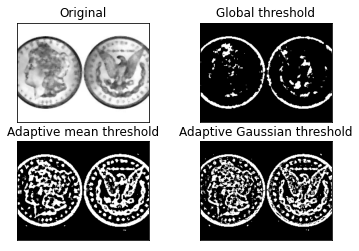

```python
ret, th1 = cv.threshold(img, 127, 255, cv.THRESH_BINARY_INV)
th2 = cv.adaptiveThreshold(img, 255, cv.ADAPTIVE_THRESH_MEAN_C,
                          cv.THRESH_BINARY_INV, 11, 2)
th3 = cv.adaptiveThreshold(img, 255, cv.ADAPTIVE_THRESH_GAUSSIAN_C,
                          cv.THRESH_BINARY_INV, 11, 2)

titles = ['Original', 'Global threshold', 'Adaptive mean threshold',
         'Adaptive Gaussian threshold']
images = [img, th1, th2, th3]

for i in range(4):
    plt.subplot(2, 2, i+1), plt.imshow(images[i], 'gray')
    plt.title(titles[i])
    plt.xticks([]), plt.yticks([])

plt.show()
```

```python
cv.countNonZero(th1)
```

```
4757
```

### Otsu's binarization

In global thresholding, we used an arbitrary chosen value as a threshold. In contrast, Otsu's method avoids having to choose a value and determines it automatically.

Consider an image with only 2 distinct image values (*bimodal image*), where the histogram would only consists of 2 peaks. A good threshold would be to select value in the middle of those 2 values. Similarly, Otsu's method determines an optimal global threshold value from the histogram.

In order to do so, the `cv.threshold()` function is used, where `cv.THRESH_OTSU` is passed as an extra flag.

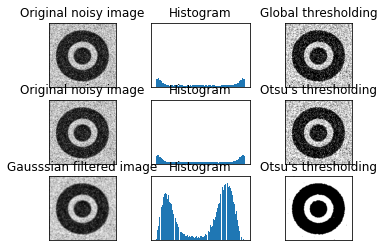

```python
img = cv.imread('noisy.jfif', 0)   # 0 means grayscale

# global threshold
ret1, th1 = cv.threshold(img, 127, 255, cv.THRESH_BINARY)

# Otsu's threshold
ret2, th2 = cv.threshold(img, 0, 255, cv.THRESH_BINARY+cv.THRESH_OTSU)

# Otsu's threshold after Gaussian filtering
blur = cv.GaussianBlur(img, (5, 5), 0)   # the third argument here is standard deviation
ret3, th3 = cv.threshold(blur, 0, 255, cv.THRESH_BINARY+cv.THRESH_OTSU)

# Plot grayscale images, their histogram and the resulting thresholded images
images = [img, 0, th1,
         img, 0, th2,
         blur, 0, th3]
titles = ['Original noisy image', 'Histogram', 'Global thresholding',
         'Original noisy image', 'Histogram', "Otsu's thresholding",
         'Gausssian filtered image', 'Histogram', "Otsu's thresholding"]

for i in range(3):
    plt.subplot(3, 3, i*3+1), plt.imshow(images[i*3], 'gray')
    plt.title(titles[i*3]), plt.xticks([]), plt.yticks([])
    plt.subplot(3, 3, i*3+2), plt.hist(images[i*3].ravel(), 256)
    plt.title(titles[i*3+1]), plt.xticks([]), plt.yticks([])
    plt.subplot(3, 3, i*3+3), plt.imshow(images[i*3+2], 'gray')
    plt.title(titles[i*3+2]), plt.xticks([]), plt.yticks([])

plt.show()
```

Thresholding can be used to isolate certain objects in an image.

## Exercise

Plot the histogram of 'wood_planck.jfif'. Then, apply thresholding to segment the wooden planck.

## Activity

Write a program to *segment the boat and the people on it from the background*. Follow the instruction below:

- Use 'boat.jpg' as input.
- Apply Otsu thresholding.
- Draw bounding box to identify the region where the boat and people are located.

# Image processing II

## Morphological Transformations

### Theory

Morphological tranformations are some simple operations based on the image shape. It is normally performed on binary images. It needs 2 inputs, one is our original image, second one is called **structuring element** or **kernel** which decides the nature of operation. Two fundamental morphological operators are *Erosion* and *Dilation*. We will reuse the noisy image in the following example.

1. Erosion  
   The kernel slides through the image (as in 2D convolution). A pixel in the original image (either 1 or 0) will be considered 1 only if all the pixels under the kernel is 1, otherwise it is eroded (made to zero). So what happens is that, all the pixels near boundary will be discarded depending upon the size of the kernel. So, the thickness or size of foreground object decreases or simply white regions decrease in the image. It is useful for removing small white noises and detach two connected objects.

```python
img = cv.imread('noisy.jfif', 0)

blur = cv.GaussianBlur(img, (5, 5), 0)
_, img_binary = cv.threshold(blur, 0, 255, cv.THRESH_BINARY_INV+cv.THRESH_OTSU)
# save in directory
kernel = np.ones((5,5), np.uint8)
erosion = cv.erode(img_binary, kernel, iterations = 1)

combined_images = np.hstack((img_binary, erosion))

cv.imshow('erosion', combined_images)
cv.waitKey(0)
cv.destroyAllWindows()
```

1. Dilation  
   It is opposite of erosion. Here, a pixel element is '1' if at least one pixel under the kernel is '1'. So, the size of foreground objects increase.

```python
dilation = cv.dilate(img_binary, kernel, iterations = 1)

combined_images = np.hstack((img_binary, dilation))
cv.imshow('combined', combined_images)
cv.waitKey(0)
cv.destroyAllWindows()
```

1. Opening  
   Opening is another name of erosion followed by dilation. It is useful for removing noise. Erosion removes white noises, but it also shrinks our object. So we dilate it. Since noise is gone, they won't come back, but our object area increases. It is also useful in joining broken parts of an object. This is done by `cv.morphologyEx()` with `cv.MORPH_OPEN` flag.
2. Closing  
   Closing is reverse of Opening, dilation followed by erosion. It is useful in closing small holes inside foreground objects. This is done by `cv.morphologyEx()` with `cv.MORPH_CLOSE` flag.
3. Morphological Gradient  
   It is the difference between dilation and erosion of an image. The result will look like an outline of an object. This is done by `cv.morphologyEx()` with `cv.MORPH_GRADIENT` flag.

### Structuring element

```python
cv.getStructuringElement(cv.MORPH_ELLIPSE, (5, 5))
```

```
array([[0, 0, 1, 0, 0],
       [1, 1, 1, 1, 1],
       [1, 1, 1, 1, 1],
       [1, 1, 1, 1, 1],
       [0, 0, 1, 0, 0]], dtype=uint8)
```

## Activity

Write a program to visualize the effect of size of structuring element on the morphological transformation (e.g. erosion, dilation, opening, and closing).

- Load the 'leaf.jfif' and perform thresholding to segment the leaf from the background.
- Create a GUI containing trackbar to control the size of structuring element and display the resulting image on a window alongside the trackbar.

## Color space / color model

In the most common color space, RGB (Red Green Blue), colors are represented in terms of their red, green, and blue components. In more technical terms, RGB describes a color as a tuple of 3 components. Each component can take a value between 0 and 255, where the tuple (0, 0, 0) represents black and (255, 255, 255) represents white. RGB is considered an "additive" color space, and colors can be imagined as being produced from shining quantities of red, blue and green light onto a black background.

There are so many color spaces because different color spaces are useful for different purposes. We will typically work with 3 kinds of color models: blue-green-red (BGR), grayscale and hue-saturation-value (HSV).

In reality, color is a continuous phenomenon, meaning that there are an infinite number of colors. Color spaces, however represent color through discrete structures (a fixed number of whole number integer values), which is acceptable since the human eye and perception are also limited.

### RGB color space

It is an additive colorspace where colors are obtained by a linear combination of Red, Green and Blue values.

There are some inherent problems asociated with RGB colorspace:

- significant perceptual non-uniformity.
- mixing of chrominance and luminance data.

### LAB color space

3 components:

- L: lightness (intensity).
- A: color component ranging from green to red.
- B: color component ranging from blue to yellow.

The L component is independent of color information and encodes brightness only.

### YCrCb color space

Like LAB colorspace, the luminance and chrominances are separated into different channels. Y is used to represent luminance (or luma), Cb represents blue-difference, and Cr represents red-difference.

### HSV / HSI color space

1. Hue is the color attribute that describes pure color.
2. Saturation is the quantity that reflect the degree to which pure color is diluted by white light.
3. Value or intensity is brightness.

The important takeaway is: *Lighting condition can mean the difference between success and failure of your computer vision algorithm.* Thus, color space which could factor out luminance into different channel should be the choice.

### Changing Color-space

There are more than 150 color-space conversion methods available in OpenCV.

```
import cv2 as cv
flags = [i for i in dir(cv) if i.startswith('COLOR_')]
print(flags)
```

## **Tips**

How to find HSV values of a certain color? Below is an example:

```
green = np.uint8([[[0,255,0]]])
hsv_green = cv.cvtColor(green, cv.COLOR_BGR2HSV)
print(hsv_green)
```

Alternatively, you can just simple use any online converters or refer to the example below.

```python
flags = [i for i in dir(cv) if i.startswith('COLOR_')]

len(flags)
```

```
346
```

## Example of color space segmentation

```python
img = cv.imread('pant.jfif')
img = cv.cvtColor(img, cv.COLOR_BGR2RGB)
img is not None
```

```
True
```

```python
# These libraries provide the functionalities you need for the plot.
from mpl_toolkits.mplot3d import Axes3D
from matplotlib import cm
from matplotlib import colors
```

The following code chunk let you set up the pixel colors. In order to color each pixel according to its true color, there's a bit of reshaping and normalization required. It looks messy, but essentially you need the colors corresponding to every pixel in the image to be flattened into a list and normalized, so that they can be passed to the `facecolors` parameter of Matplotlib `scatter()`.

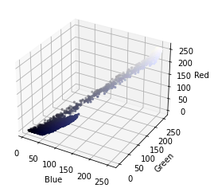

```python
r, g, b = cv.split(img)
fig = plt.figure()
axis = fig.add_subplot(1, 1, 1, projection = "3d")

pixel_colors = img.reshape((img.shape[0]*img.shape[1], 3))
norm = colors.Normalize(vmin = -1., vmax=1.)
norm.autoscale(pixel_colors)
pixel_colors = norm(pixel_colors).tolist()

axis.scatter(b.flatten(), g.flatten(), r.flatten(), facecolors = pixel_colors,
            marker = ".")
axis.set_xlabel('Blue')
axis.set_ylabel('Green')
axis.set_zlabel('Red')
plt.show()
```

```python
min(pixel_colors)
```

```
[0.0, 0.0, 0.027450980618596077]
```

### Visualizing Pant in HSV color space

As mentioned above, HSV stands for Hue, Saturation and Value and is a cylindrical color space. The colors, or hues are modeled as an angular dimension rotating around a central vertical axis which represent the value channel. Values go from dark to light at the top. The third axis, saturation defines the shades of hue from least saturated, at the vertical axis to the most saturated from the center.

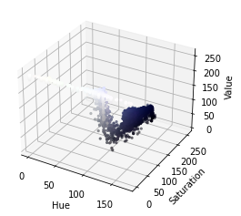

```python
img_hsv = cv.cvtColor(img, cv.COLOR_RGB2HSV)

h, s, v = cv.split(img_hsv)
fig = plt.figure()
axis = fig.add_subplot(1, 1, 1, projection = "3d")

axis.scatter(h.flatten(), s.flatten(), v.flatten(), facecolors = pixel_colors,
            marker = ".")
axis.set_xlabel("Hue")
axis.set_ylabel("Saturation")
axis.set_zlabel("Value")
plt.show()
```

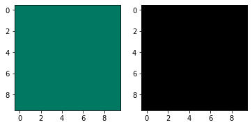

```python
blue_low = (70, 120, 0)
blue_high = (120, 255, 120)

from matplotlib.colors import hsv_to_rgb

lo_square = np.full((10, 10, 3), blue_low, dtype = np.uint8)/255.0
do_square = np.full((10, 10, 3), blue_high, dtype = np.uint8)/255.0

plt.subplot(1, 2, 1)
plt.imshow(hsv_to_rgb(do_square))
plt.subplot(1,2,2)
plt.imshow(hsv_to_rgb(lo_square))
plt.show()
```

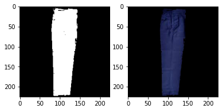

```python
mask = cv.inRange(img_hsv, blue_low, blue_high)
res = cv.bitwise_and(img, img, mask = mask)

plt.subplot(1,2,1)
plt.imshow(mask, cmap = 'gray')
plt.subplot(1,2,2)
plt.imshow(res)
plt.show()
```

## Exercise

- Does the segmentation generalize to other blue pant images?
  - Import all blue pant images ("pant1.jfif" - "pant5.jfif")
  - Perform color segmentation
  - Display the results

The results should be as shown below:

[figure not shown]

## Activity

- Apply the steps shown above the segment the porcelain from these images: "porcelain1.jfif" - "porcelain5.jfif"

# Weekly activity